# Data Analysis Assignment #1 (50 points total)

roy, deblina

Submit both the .Rmd and .html files for grading. You may remove the instructions and example problem above, but do not remove the YAML metadata block or the first, “setup” code chunk. Address the steps that appear below and answer all the questions. Be sure to address each question with code and comments as needed. You may use either base R functions or ggplot2 for the visualizations.

The following code chunk will:

1. load the “ggplot2”, “gridExtra” and “knitr” packages, assuming each has been installed on your machine,
2. read-in the abalones dataset, defining a new data frame, “mydata,”
3. return the structure of that data frame, and
4. calculate new variables, VOLUME and RATIO.

Do not include package installation code in this document. Packages should be installed via the Console or ‘Packages’ tab. You will also need to download the abalones.csv from the course site to a known location on your machine. Unless a *file.path()* is specified, R will look to directory where this .Rmd is stored when knitting.

```
## 'data.frame':    1036 obs. of  8 variables:
##  $ SEX   : Factor w/ 3 levels "F","I","M": 2 2 2 2 2 2 2 2 2 2 ...
##  $ LENGTH: num  5.57 3.67 10.08 4.09 6.93 ...
##  $ DIAM  : num  4.09 2.62 7.35 3.15 4.83 ...
##  $ HEIGHT: num  1.26 0.84 2.205 0.945 1.785 ...
##  $ WHOLE : num  11.5 3.5 79.38 4.69 21.19 ...
##  $ SHUCK : num  4.31 1.19 44 2.25 9.88 ...
##  $ RINGS : int  6 4 6 3 6 6 5 6 5 6 ...
##  $ CLASS : Factor w/ 5 levels "A1","A2","A3",..: 1 1 1 1 1 1 1 1 1 1 ...
```

### Test Items starts from here - There are 6 sections - Total 50 points

*##### Section 1: (6 points) Summarizing the data.*

(1)(a) (1 point) Use *summary()* to obtain and present descriptive statistics from mydata. Use *table()* to present a frequency table using CLASS and RINGS. There should be 115 cells in the table you present.

```
##  SEX         LENGTH           DIAM            HEIGHT          WHOLE
##  F:326   Min.   : 2.73   Min.   : 1.995   Min.   :0.525   Min.   :  1.625
##  I:329   1st Qu.: 9.45   1st Qu.: 7.350   1st Qu.:2.415   1st Qu.: 56.484
##  M:381   Median :11.45   Median : 8.925   Median :2.940   Median :101.344
##          Mean   :11.08   Mean   : 8.622   Mean   :2.947   Mean   :105.832
##          3rd Qu.:13.02   3rd Qu.:10.185   3rd Qu.:3.570   3rd Qu.:150.319
##          Max.   :16.80   Max.   :13.230   Max.   :4.935   Max.   :315.750
##      SHUCK              RINGS        CLASS        VOLUME
##  Min.   :  0.5625   Min.   : 3.000   A1:108   Min.   :  3.612
##  1st Qu.: 23.3006   1st Qu.: 8.000   A2:236   1st Qu.:163.545
##  Median : 42.5700   Median : 9.000   A3:329   Median :307.363
##  Mean   : 45.4396   Mean   : 9.993   A4:188   Mean   :326.804
##  3rd Qu.: 64.2897   3rd Qu.:11.000   A5:175   3rd Qu.:463.264
##  Max.   :157.0800   Max.   :25.000            Max.   :995.673
##      RATIO
##  Min.   :0.06734
##  1st Qu.:0.12241
##  Median :0.13914
##  Mean   :0.14205
##  3rd Qu.:0.15911
##  Max.   :0.31176
```

```
##
##        3   4   5   6   7   8   9  10  11  12  13  14  15  16  17  18  19  20
##   A1   9   8  24  67   0   0   0   0   0   0   0   0   0   0   0   0   0   0
##   A2   0   0   0   0  91 145   0   0   0   0   0   0   0   0   0   0   0   0
##   A3   0   0   0   0   0   0 182 147   0   0   0   0   0   0   0   0   0   0
##   A4   0   0   0   0   0   0   0   0 125  63   0   0   0   0   0   0   0   0
##   A5   0   0   0   0   0   0   0   0   0   0  48  35  27  15  13   8   8   6
##
##       21  22  23  24  25
##   A1   0   0   0   0   0
##   A2   0   0   0   0   0
##   A3   0   0   0   0   0
##   A4   0   0   0   0   0
##   A5   4   1   7   2   1
```

**Question (1 point): Briefly discuss the variable types and distributional implications such as potential skewness and outliers.**

***Answer: ( The dataset contains both categorical and numerical variables. SEX and CLASS are categorical variables—SEX is nominal and balanced across categories (F, M, I), while CLASS is ordinal and Distribution is concentrated in middle age groups, not strongly skewed. Continuous variables include LENGTH, DIAM, and HEIGHT, all showing nearly symmetric distributions with close mean and median values and no major skewness or outliers. Variables like WHOLE, SHUCK, and VOLUME are continuous and show signs of positive skew and possible upper-end outliers due to large value ranges. RINGS is a discrete numeric variable with a slight positive skew indicating more young abalones than older ones. RATIO, though also continuous, has a narrow range and slight positive skew but no extreme outliers. Overall, while most variables are symmetric, skewness and outliers appear in weight-related measures (WHOLE, SHUCK, VOLUME) and age (RINGS).

)***

(1)(b) (1 point) Generate a table of counts using SEX and CLASS. Add margins to this table (Hint: There should be 15 cells in this table plus the marginal totals. Apply *table()* first, then pass the table object to *addmargins()* (Kabacoff Section 7.2 pages 144-147)). Lastly, present a barplot of these data; ignoring the marginal totals.

```
##
##         A1   A2   A3   A4   A5  Sum
##   F      5   41  121   82   77  326
##   I     91  133   65   21   19  329
##   M     12   62  143   85   79  381
##   Sum  108  236  329  188  175 1036
```

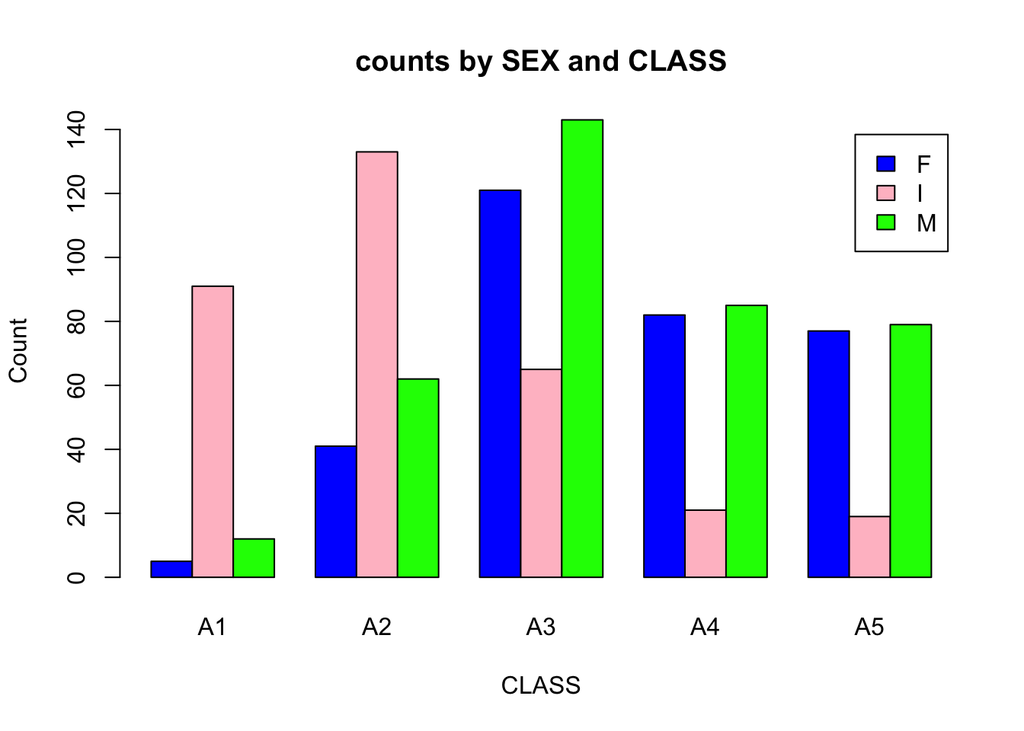

**Essay Question (2 points): Discuss the sex distribution of abalones. What stands out about the distribution of abalones by CLASS?**

***Answer: ( The sex distribution of abalones across CLASS categories reveals important patterns related to growth, development, and maturation:

1. Infants Dominate Early Classes: In Class A1, the vast majority of abalones are labeled as Infants (I). This strongly suggests that A1 corresponds to the earliest developmental stage. Class A2 still has a large number of Infants, but Males (M) begin to appear in higher numbers, indicating the start of sexual differentiation.
   2. Transition to Adulthood in Mid Classes: In Class A3, the distribution shifts significantly - Males and Females (F) surpass Infants in count. This class appears to be a transitional stage, where abalones mature from the Infant stage to identifiable adult sexes. Notably, Males outnumber Females, suggesting either a biological tendency or a sampling effect.
   3. Adult Stability in Higher Classes: Classes A4 and A5 show minimal Infant presence. These classes are predominantly composed of Males and Females, with Males slightly more prevalent. This points to a more stable sex distribution among mature abalones.
   4. Sex Imbalance Across Classes: While overall the sexes are somewhat balanced, there is a consistent trend of Males being more numerous than Females in older classes (A3 to A5). This could reflect faster growth, better survival rates, or differences in classification accuracy between sexes.

What stands out is that the dataset clearly reflects a biological progression: - Infants are concentrated in early classes, - Adults emerge by Class A3, - And by Classes A4 and A5, the population is composed almost entirely of Males and Females, with Males becoming slightly dominant. )***

(1)(c) (1 point) Select a simple random sample of 200 observations from “mydata” and identify this sample as “work.” Use *set.seed(123)* prior to drawing this sample. Do not change the number 123. Note that *sample()* “takes a sample of the specified size from the elements of x.” We cannot sample directly from “mydata.” Instead, we need to sample from the integers, 1 to 1036, representing the rows of “mydata.” Then, select those rows from the data frame (Kabacoff Section 4.10.5 page 87).

Using “work”, construct a scatterplot matrix of variables 2-6 with *plot(work[, 2:6])* (these are the continuous variables excluding VOLUME and RATIO). The sample “work” will not be used in the remainder of the assignment.

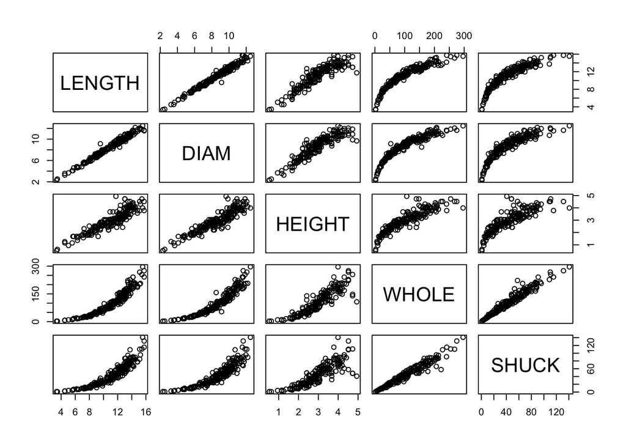

*##### Section 2: (5 points) Summarizing the data using graphics.*

(2)(a) (1 point) Use “mydata” to plot WHOLE versus VOLUME. Color code data points by CLASS.

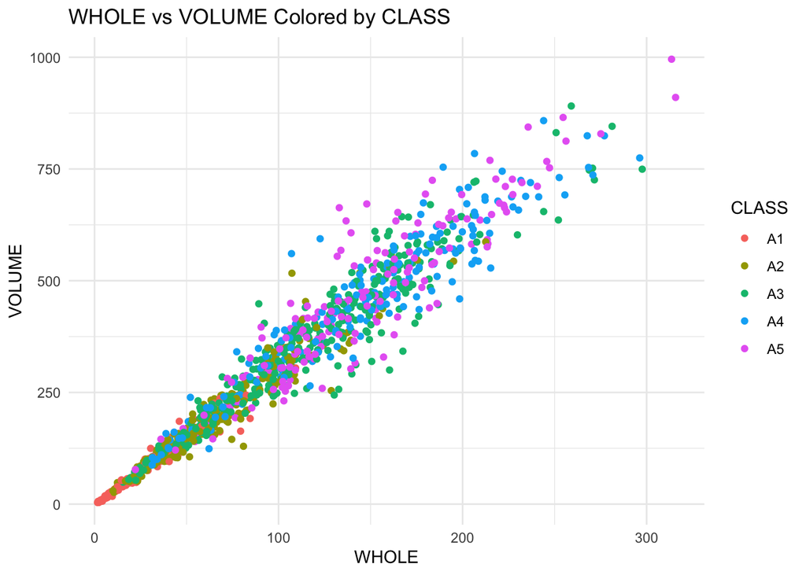

(2)(b) (2 points) Use “mydata” to plot SHUCK versus WHOLE with WHOLE on the horizontal axis. Color code data points by CLASS. As an aid to interpretation, determine the maximum value of the ratio of SHUCK to WHOLE. Add to the chart a straight line with zero intercept using this maximum value as the slope of the line. If you are using the ‘base R’ *plot()* function, you may use *abline()* to add this line to the plot. Use *help(abline)* in R to determine the coding for the slope and intercept arguments in the functions. If you are using ggplot2 for visualizations, *geom_abline()* should be used.

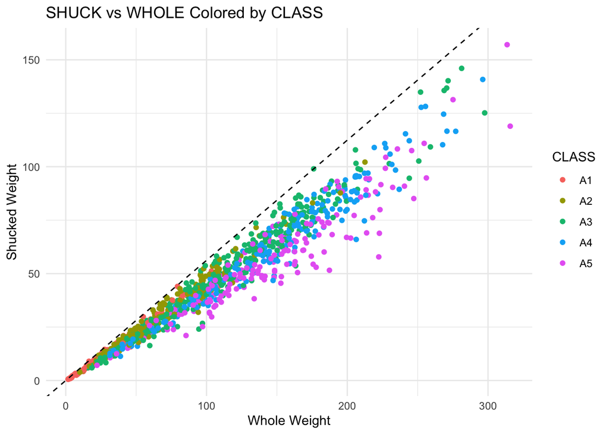

**Essay Question (2 points): How does the variability in this plot differ from the plot in (a)? Compare the two displays. Keep in mind that SHUCK is a part of WHOLE. Consider the location of the different age classes.**

***Answer: ( Plot 2(a): WHOLE vs VOLUME - Structure of the Relationship: WHOLE and VOLUME have a strong positive correlation, but the relationship is less tightly linear. The points show wider vertical spread (greater variability in VOLUME for a given WHOLE weight). - Interpretation of Variability: Since VOLUME is derived from physical dimensions (LENGTH × DIAM × HEIGHT), while WHOLE is a weight, these two measures are related but not perfectly proportionate. Shape variation in abalones (e.g., same weight but different shapes) introduces natural variability in VOLUME. Different age classes (CLASS A1 to A5) are somewhat scattered across the WHOLE-VOLUME relationship, with older classes (A4, A5) tending to cluster at higher values.

Plot 2(b): SHUCK vs WHOLE - Structure of the Relationship: This plot shows a tighter, bounded linear relationship, because SHUCK is a component of WHOLE. The maximum possible SHUCK cannot exceed WHOLE, which naturally restricts the range of the SHUCK values. The dashed line reflects the max SHUCK-to-WHOLE ratio as a constraint. - Interpretation of Variability: Much less scatter compared to plot 2(a); data points are tightly concentrated below the dashed line. Indicates that SHUCK is highly dependent on WHOLE, but with some variation based on internal composition. Age classes (CLASS) are more clearly separated vertically: as abalones age, both SHUCK and WHOLE increase, but within a more predictable range than in the VOLUME case.

## )***

*### Section 3: (8 points) Getting insights about the data using graphs.*

(3)(a) (2 points) Use “mydata” to create a multi-figured plot with histograms, boxplots and Q-Q plots of RATIO differentiated by sex. This can be done using *par(mfrow = c(3,3))* and base R or *grid.arrange()* and ggplot2. The first row would show the histograms, the second row the boxplots and the third row the Q-Q plots. Be sure these displays are legible.

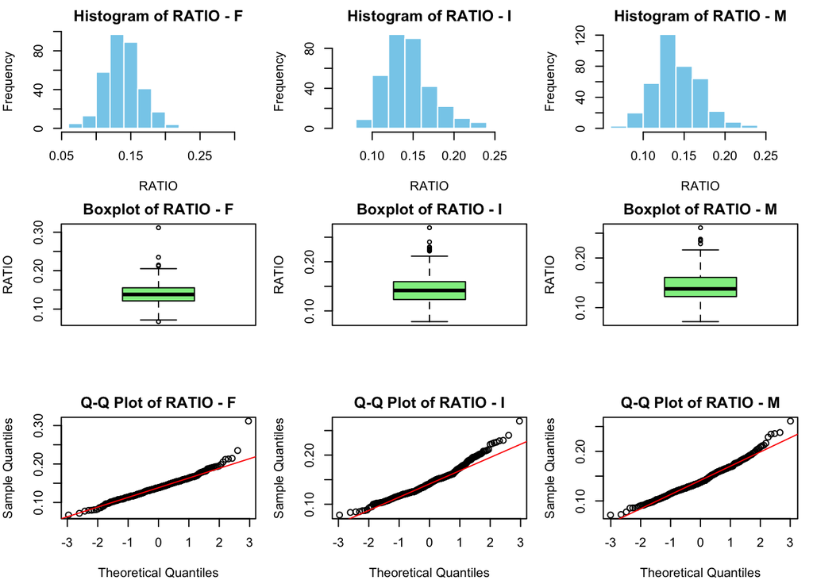

**Essay Question (2 points): Compare the displays. How do the distributions compare to normality? Take into account the criteria discussed in the sync sessions to evaluate non-normality.**

***Answer: ( Histogram Observations: - All three histograms (F, I, M) show slight right-skewness, meaning the distribution tails off to the right with more data concentrated toward the left. - The distributions are unimodal but not perfectly symmetric, especially for Infants, where a small bump at the higher end suggests potential bimodality.

Boxplot Observations: - Each sex group shows visible outliers (above the upper whisker), particularly among Infants and Females. - The median lines are not centered in the boxes, further indicating skewness. - Infants exhibit more spread and a wider interquartile range, suggesting more variability in the RATIO.

Q-Q Plot Observations: - For all three sexes, the Q-Q plots show deviations from the straight red line, especially in the tails: - Heavy tails are present (points deviate at the ends), meaning the data have more extreme values than a normal distribution would expect. - S-shaped patterns confirm departures from normality—indicating skewness or kurtosis. - Infants have the most pronounced departure from normality.

Overall, - The RATIO variable does not follow a normal distribution for any of the sex categories. - There is moderate right-skewness, especially for Infants, and outliers that further distort normality assumptions. - Based on criteria discussed in sync session (e.g. symmetry, absence of heavy tails), none of the groups can be assumed to be normally distributed. Therefore, it is recommended to consider transformations or apply non-parametric methods if the analysis requires the assumption of normality. )***

(3)(b) (2 points) The boxplots in (3)(a) indicate that there are outlying RATIOs for each sex. *boxplot.stats()* can be used to identify outlying values of a vector. Present the abalones with these outlying RATIO values along with their associated variables in “mydata”. Display the observations by passing a data frame to the kable() function. Basically, we want to output those rows of “mydata” with an outlying RATIO, but we want to determine outliers looking separately at infants, females and males.

Outlying RATIO values by Sex

|  | SEX | LENGTH | DIAM | HEIGHT | WHOLE | SHUCK | RINGS | CLASS | VOLUME | RATIO |
| --- | --- | --- | --- | --- | --- | --- | --- | --- | --- | --- |
| F.350 | F | 7.980 | 6.720 | 2.415 | 80.93750 | 40.37500 | 7 | A2 | 129.505824 | 0.3117620 |
| F.379 | F | 15.330 | 11.970 | 3.465 | 252.06250 | 134.89812 | 10 | A3 | 635.827846 | 0.2121614 |
| F.420 | F | 11.550 | 7.980 | 3.465 | 150.62500 | 68.55375 | 10 | A3 | 319.365585 | 0.2146560 |
| F.421 | F | 13.125 | 10.290 | 2.310 | 142.00000 | 66.47062 | 9 | A3 | 311.979938 | 0.2130606 |
| F.458 | F | 11.445 | 8.085 | 3.150 | 139.81250 | 68.49062 | 9 | A3 | 291.478399 | 0.2349767 |
| F.586 | F | 12.180 | 9.450 | 4.935 | 133.87500 | 38.25000 | 14 | A5 | 568.023435 | 0.0673388 |
| I.3 | I | 10.080 | 7.350 | 2.205 | 79.37500 | 44.00000 | 6 | A1 | 163.364040 | 0.2693371 |
| I.37 | I | 4.305 | 3.255 | 0.945 | 6.18750 | 2.93750 | 3 | A1 | 13.242072 | 0.2218308 |
| I.42 | I | 2.835 | 2.730 | 0.840 | 3.62500 | 1.56250 | 4 | A1 | 6.501222 | 0.2403394 |
| I.58 | I | 6.720 | 4.305 | 1.680 | 22.62500 | 11.00000 | 5 | A1 | 48.601728 | 0.2263294 |
| I.67 | I | 5.040 | 3.675 | 0.945 | 9.65625 | 3.93750 | 5 | A1 | 17.503290 | 0.2249577 |
| I.89 | I | 3.360 | 2.310 | 0.525 | 2.43750 | 0.93750 | 4 | A1 | 4.074840 | 0.2300704 |
| I.105 | I | 6.930 | 4.725 | 1.575 | 23.37500 | 11.81250 | 7 | A2 | 51.572194 | 0.2290478 |
| I.200 | I | 9.135 | 6.300 | 2.520 | 74.56250 | 32.37500 | 8 | A2 | 145.027260 | 0.2232339 |
| M.746 | M | 13.440 | 10.815 | 1.680 | 130.25000 | 63.73125 | 10 | A3 | 244.194048 | 0.2609861 |
| M.754 | M | 10.500 | 7.770 | 3.150 | 132.68750 | 61.13250 | 9 | A3 | 256.992750 | 0.2378764 |
| M.803 | M | 10.710 | 8.610 | 3.255 | 160.31250 | 70.41375 | 9 | A3 | 300.153640 | 0.2345924 |
| M.810 | M | 12.285 | 9.870 | 3.465 | 176.12500 | 99.00000 | 10 | A3 | 420.141472 | 0.2356349 |
| M.852 | M | 11.550 | 8.820 | 3.360 | 167.56250 | 78.27187 | 10 | A3 | 342.286560 | 0.2286735 |

**Essay Question (2 points): What are your observations regarding the results in (3)(b)?**

*Answer: ( The analysis in (3)(b) identifies outliers in the RATIO variable (defined as SHUCK weight divided by VOLUME) separately for each sex (F, M, I). These outliers are extreme values in their respective groups. Females (F): - Most outliers in females have very large SHUCK weights relative to their volume, pushing their RATIO values higher. - One female (F.586) stands out as a low-end outlier with a very small RATIO (~0.067), despite having a large VOLUME and SHUCK weight. This could be due to mismeasurement or a biologically atypical case. Infants (I): - Outliers here tend to have very small body sizes (e.g., LENGTH < 5 cm) but relatively higher SHUCK weights, making their RATIO higher. - Since infants are not fully developed, small variations in SHUCK weight can greatly impact the RATIO, explaining their sensitivity to outlier detection. Males (M): - Male outliers have moderately large volumes and high SHUCK weights, indicating better-than-average yield. - Their RATIO values are more tightly clustered, suggesting less variability in body efficiency among males compared to infants. )*

*### Section 4: (8 points) Getting insights about possible predictors.*

(4)(a) (3 points) With “mydata,” display side-by-side boxplots for VOLUME and WHOLE, each differentiated by CLASS There should be five boxes for VOLUME and five for WHOLE. Also, display side-by-side scatterplots: VOLUME and WHOLE versus RINGS. Present these four figures in one graphic: the boxplots in one row and the scatterplots in a second row. Base R or ggplot2 may be used.

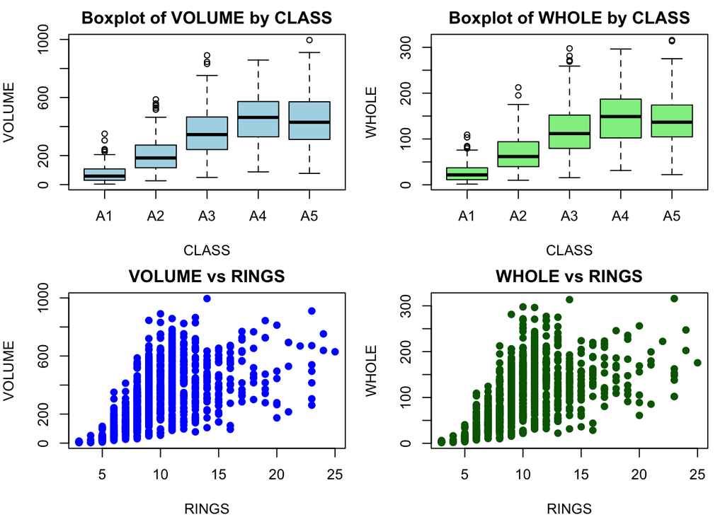

**Essay Question (5 points) How well do you think these variables would perform as predictors of age? Explain.**

***Answer: ( Based on the plot analysis-

In conclusion, both VOLUME and WHOLE weight can be useful for predicting the age of abalones (measured by RINGS): - As abalones get older, their VOLUME and WHOLE weight generally increase, which means these are good indicators of age. - This is clearly seen in the boxplots, where older classes (A4, A5) have higher values. - In the scatterplots, we see that as RINGS go up, VOLUME and WHOLE weight also go up — especially between RINGS 5 and 15.

However: - The data becomes more spread out for older abalones. So, while these variables work well for younger and middle-aged abalones, they are less accurate for predicting the age of older ones. - VOLUME might be slightly better than WHOLE, because it includes length, diameter, and height — giving a fuller picture of the abalone’s size.

Overall, VOLUME and WHOLE are good predictors of age, especially for younger abalones, but they become less reliable as abalones get older.

)***

*### Section 5: (12 points) Getting insights regarding different groups in the data.*

(5)(a) (2 points) Use *aggregate()* with “mydata” to compute the mean values of VOLUME, SHUCK and RATIO for each combination of SEX and CLASS. Then, using *matrix()*, create matrices of the mean values. Using the “dimnames” argument within *matrix()* or the *rownames()* and *colnames()* functions on the matrices, label the rows by SEX and columns by CLASS. Present the three matrices (Kabacoff Section 5.6.2, p. 110-111). The *kable()* function is useful for this purpose. You do not need to be concerned with the number of digits presented.

Mean VOLUME by SEX and CLASS

[output not shown]

Mean SHUCK by SEX and CLASS

[output not shown]

Mean RATIO by SEX and CLASS

[output not shown]

(5)(b) (3 points) Present three graphs. Each graph should include three lines, one for each sex. The first should show mean RATIO versus CLASS; the second, mean VOLUME versus CLASS; the third, mean SHUCK versus CLASS. This may be done with the ‘base R’ *interaction.plot()* function or with ggplot2 using *grid.arrange()*.

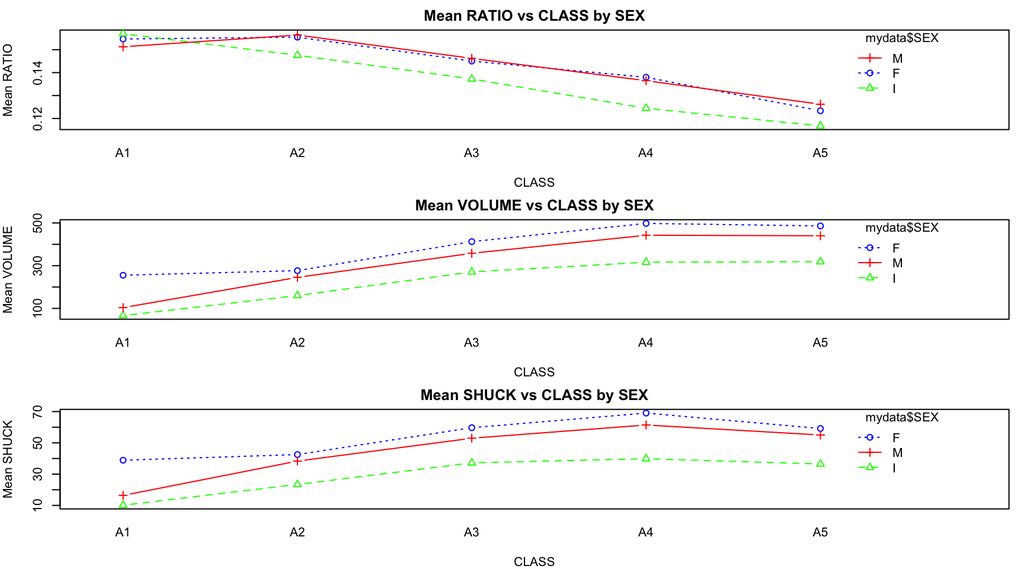

**Essay Question (2 points): What questions do these plots raise? Consider aging and sex differences.**

[output not shown]

These insights suggest the need for further biological investigation into growth dynamics, sex differentiation, and classification accuracy in the dataset. )***

5(c) (3 points) Present four boxplots using *par(mfrow = c(2, 2)* or *grid.arrange()*. The first line should show VOLUME by RINGS for the infants and, separately, for the adult; factor levels “M” and “F,” combined. The second line should show WHOLE by RINGS for the infants and, separately, for the adults. Since the data are sparse beyond 15 rings, limit the displays to less than 16 rings. One way to accomplish this is to generate a new data set using subset() to select RINGS < 16. Use ylim = c(0, 1100) for VOLUME and ylim = c(0, 400) for WHOLE. If you wish to reorder the displays for presentation purposes or use ggplot2 go ahead.

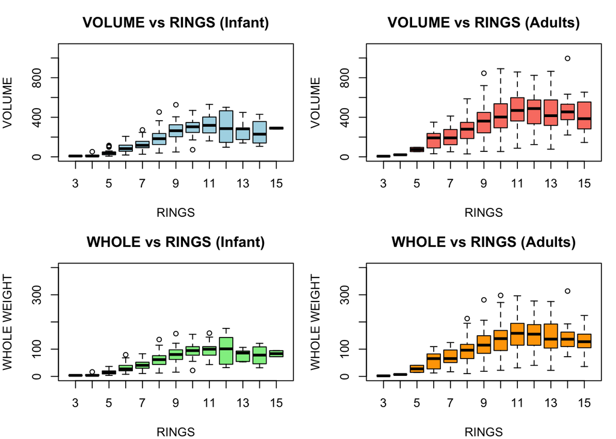

**Essay Question (2 points): What do these displays suggest about abalone growth? Also, compare the infant and adult displays. What differences stand out?**

***Answer: ( The boxplots provide meaningful insights into abalone growth patterns - - Volume and Whole weight both increase with RINGS (age), showing a strong positive relationship between physical size and age. - Growth appears nonlinear: - Rapid increases occur between RINGS 3-10. - Beyond RINGS 11, growth slows or plateaus, especially in VOLUME.

)***

*### Section 6: (11 points) Conclusions from the Exploratory Data Analysis (EDA).*

**Essay Question 1) (5 points) Based solely on these data, what are plausible statistical reasons that explain the failure of the original study? Consider to what extent physical measurements may be used for age prediction.**

***Answer:( There are several plausible statistical explanations for why the original study may have failed in accurately predicting abalone age from physical characteristics:

[output not shown]

```
- Non-normality of RATIO:
```

From the histograms, boxplots, and Q-Q plots by sex (Image 5), the RATIO variable deviates from normality with outliers and skewness. Since many models assume normality, this affects predictive reliability.

```
- Overlap between groups:
```

Scatterplots (Images 3, 4) show a strong correlation between WHOLE, VOLUME, and SHUCK weights, but there’s significant overlap across CLASS levels. This makes it hard to clearly distinguish between age classes using just physical measures.

[output not shown]

[output not shown]

[output not shown]

Conclusion: While physical characteristics are correlated with age, overlap, variability, and biological differences limit their accuracy. This likely explains the failure of the original study’s predictive model.

)***

**Essay Question 2) (3 points) Do not refer to the abalone data or study. If you were presented with an overall histogram and summary statistics from a sample of some population or phenomenon and no other information, what questions might you ask before accepting them as representative of the sampled population or phenomenon?**

***Answer: ( Before accepting summary statistics and a histogram as representative of a population or phenomenon, I might have asked:

1.How was the sample collected? - Was the sampling method random, stratified, or convenience-based? Sampling bias can lead to misleading conclusions.

2.What is the sample size? - A small sample size may not capture the true variability or structure of the population.

3.Does the histogram show skewness or outliers? - Averages and standard deviations can be misleading in the presence of skewed distributions or extreme values.

4. Are there any known subgroups?
- If the population includes multiple categories (e.g., age groups, regions), summary statistics for the overall sample might hide important patterns.

  5.Is there missing data or data quality issues?
- Summary statistics may be based on incomplete or inconsistent records. Knowing data quality is essential before trusting the results.

  6.What is the context or purpose of analysis?
- Without understanding the question being asked, it’s hard to judge whether the summary captures relevant information. )***

**Essay Question 3) (3 points) Do not refer to the abalone data or study. What do you see as difficulties analyzing data derived from observational studies? Can causality be determined? What might be learned from such studies?**

***Answer: ( Observational studies pose several challenges for analysis, particularly when it comes to establishing causality. Unlike experimental studies, observational data is collected without random assignment or controlled conditions. As a result, it is difficult if not impossible to draw definitive causal conclusions from such data. Instead, we can only identify associations or correlations between variables.

One major difficulty is the presence of confounding variables - unobserved factors that may influence both the independent and dependent variables. For example, a relationship between two variables might actually be driven by a third, unmeasured factor. Without the ability to control for all confounders, the risk of misleading interpretations increases.

Another concern is selection bias. Since participants in observational studies are not randomly selected or assigned, the sample may not represent the broader population. This limits the generalizability of findings. Measurement bias may also arise if the tools or methods used to collect data vary in accuracy or consistency across observations.

Despite these limitations, observational studies are incredibly valuable. They allow researchers to study real-world behavior and outcomes where experimentation is not feasible due to ethical, practical, or financial constraints. These studies can uncover meaningful patterns, inform policy decisions, and generate hypotheses for further experimental testing.

In summary, while observational studies do not support causal claims on their own, they play a crucial role in exploratory research and can provide strong evidence for relationships worth investigating in more controlled settings. )***